# Practical Machine Learning Course Project

Ray Cai

December 25, 2015

# Background

Using devices such as Jawbone Up, Nike FuelBand, and Fitbit it is now possible to collect a large amount of data about personal activity relatively inexpensively. These type of devices are part of the quantified self movement – a group of enthusiasts who take measurements about themselves regularly to improve their health, to find patterns in their behavior, or because they are tech geeks. One thing that people regularly do is quantify how much of a particular activity they do, but they rarely quantify how well they do it. In this project, my goal is to use data from accelerometers on the belt, forearm, arm, and dumbell of 6 participants. They were asked to perform barbell lifts correctly and incorrectly in 5 different ways.

# Data Preparation

This project is to build a prediction model which used to predict the manner in which people did the barbell exercise. We categorize the manner in which people did the barbell exercise into 5 classes **A**, **B**, **C**, **D** and **E**. **A** is the best, **E** is the worst.

## Getting Data

```r
require(caret,quietly=TRUE)
require(MASS,quietly = TRUE)
require(knitr,quietly=TRUE)
knitr::opts_chunk$set(cache=TRUE)
set.seed(12345)
data<-read.csv('pml-training.csv',header=TRUE)
```

The data for this project come from this source: http://groupware.les.inf.puc-rio.br/har. The raw data has 19622 measurements, each measurement has 159 variables.

## Clean Data

```r
# the threshold of NA/empty value
naValuePercentThreshold<-0.10;

data<-data[,3:length(colnames(data))]
data$cvtd_timestamp<-factor(as.numeric(strptime(data$cvtd_timestamp, "%d/%m/%Y %H:%M")))
naCounts<-sapply(data,FUN=function(x){
  sum(is.na(x) | x=="")
})

data<-data[,naCounts/nrow(data)<naValuePercentThreshold]

data<-na.omit(data)
```

Obviously, the data set is not clean data set. There is much NA and empty value. Therefore I tidy train data set by below steps:

1. Exclude variable **username**, it’s obbious unrelated to the outcome
2. Convert timestamp from string to long
3. Exclude variables which contains more than 10% NA/empty value
4. Omit measurements which contain NA values

After tidy, I got 58 variables and 19622 measurements data set.

## Split Data

| Data Set | # of measurements(# of row) | # of varaibles(# of column) | % of Total Data |
| --- | --- | --- | --- |
| Train Data | 15699 | 58 | 80% |
| Test Data | 3923 | 58 | 20% |

# Explore Feature

## Filter feature by requirement

```r
includedVariableIndex<-grepl("belt|arm|dumbell|classe",colnames(trainData))
trainData<-trainData[,includedVariableIndex]
```

## Filter feature by variance

Features which have high variance and high uniqueness are more helpful to distinguish the class. In contrast, low variance and low uniqueness features are less helpful to predict outcome. Calculated variance of candidates features, there is 0 features have near zero varaince, exclude them.

Plot relationships between features and outcome, From the plot below, all features have realtively similar distribution among the 5 outcome levels(**A**,**B**,**C**,**D**,**E**).

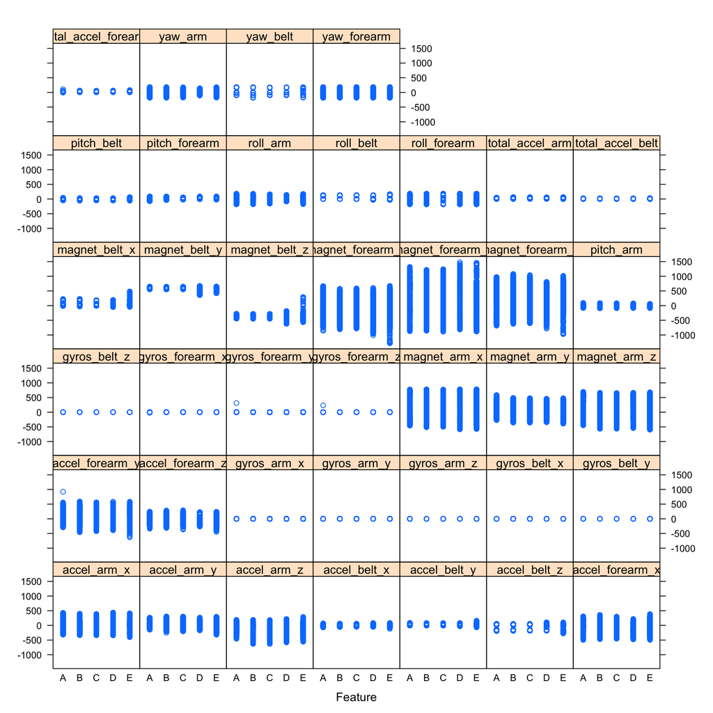

```r
featurePlot(trainData[,-ncol(trainData)],trainData$classe,"strip")
```

Plot correlation matrix between features, found there is only a few features are high correlated (heavy red rectanguler on plot). Therefore I choose to not performa further PCA preprocessing.

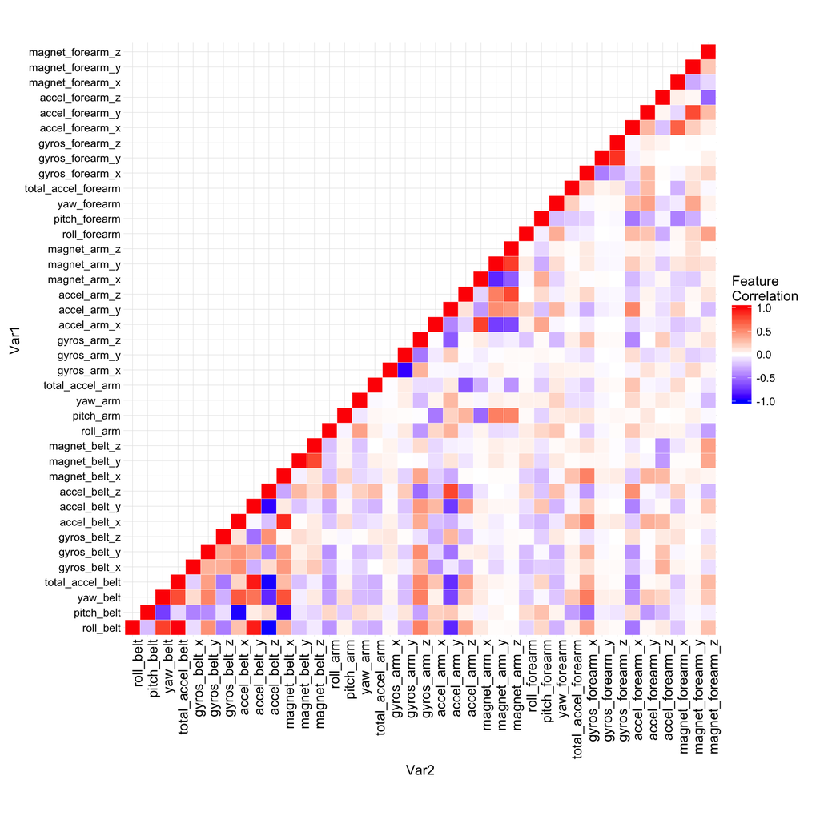

```r
library(reshape2)
library(ggplot2)

# Get upper triangle of the correlation matrix
get_upper_tri <- function(cormat){
    cormat[lower.tri(cormat)]<- NA
    return(cormat)
}
cormat <- round(cor(trainData[,-ncol(trainData)]),2)
upper_tri <- get_upper_tri(cormat)
melted_cormat <- melt(upper_tri, na.rm = TRUE)
# Heatmap
ggplot(data = melted_cormat, aes(Var2, Var1, fill = value))+
 geom_tile(color = "white")+
 scale_fill_gradient2(low = "blue", high = "red", mid = "white",
   midpoint = 0, limit = c(-1,1), space = "Lab",
   name="Feature\nCorrelation") +
  theme_minimal()+
 theme(axis.text.x = element_text(angle = 90, vjust = 1,
    size = 12, hjust = 1))+
 coord_fixed()
```

# Train Model

```r
require(randomForest,quietly=TRUE)
trainControl <- trainControl(method="repeatedcv", p=0.75)
trainTime<-system.time(
  modelFit<-train(classe~.,data=trainData,method="rf",trControl=trainControl,verbose=TRUE)
)
predictionByModelFit<-predict(modelFit,testData)
cmModelFit<-confusionMatrix(predictionByModelFit,testData$classe)
```

Expected error rate is less than `1%` fro a good classification. Train a model to predict activity quality(`classe` outcome) from 39 features by using Random Forest algrithm. With cross validation by method `repeatedcv`. I got a model which with OOB estimate of error rate: 0.8089687%, less than the threshold `1%`. Therefore the model satisified the requirement.

# Verify Model

```r
testResult<-predict(modelFit,testData)
testCM<-confusionMatrix(testResult,testData$classe)
```

```r
testCM$byClass[,1:2]
```

```
##          Sensitivity Specificity
## Class: A   0.9973118   0.9985750
## Class: B   0.9947299   0.9981037
## Class: C   0.9912281   0.9966039
## Class: D   0.9860031   0.9993902
## Class: E   0.9986130   1.0000000
```